# R與Py交互使用

### ipython notebook 包容不同運算核心

- 一份 ipy notebook 可以隨時切換與執行不同資料科學語言環境
- 例如 Python、R、Julia

```python
# python 2.7.5 執行

python = "Hi I am Python2"
print python
```

```
Hi I am Python2
```

```python
# python 3.7 執行

python = "Hi I am Python3"
print(python)
```

```
Hi I am Python3
```

```python
# R 執行

R <- "Hi I am R"
print(R)
```

```
[1] "Hi I am R"
```

## 透過 rpy2 讓 python 與 R 進行快速互動與傳值

大致上有兩種方法可以使用

1. 引入 robjects 物件
2. 引入 rpy2.ipython 物件

```python
# 引入套件 InteractiveShell 方便快速查看結果

from IPython.core.interactiveshell import InteractiveShell
InteractiveShell.ast_node_interactivity = "all"
```

```python
# 先使用第一種方式 - 引入 robjects 物件

# 載入 r object
from rpy2 import robjects

# 全域物件 r
r = robjects.r

# 定義r func 與 r var
r(
    '''
    f <- function(r){pi * r}
    test <- 'hi'
    '''
)
```

StrVector with 1 elements.

| 'hi' |
| --- |

```python
# 丟給 python

a = r['test']
b = r['f']

print(type(a),a)
print(type(b),b)
```

```
<class 'rpy2.robjects.vectors.StrVector'> [1] "hi"

<class 'rpy2.robjects.functions.SignatureTranslatedFunction'> function(r){pi * r}
```

# R 與 py 數據類型互轉

通常，可以將python的list對象，轉換成為R的vector對象 【robjects.ListVector()將python的字典轉換成R的列表】，之後直接使用R函數調用。 rpy2提供了幾個類，供我們把Python的list轉換成R的Vector。

相應的函數，如下：

```
robjects.StrVector()
robjects.IntVector()
robjects.FloatVector()
robjects.complexVector()
robjects.FactorVector()
robjects.BoolVector()
robjects.ListVector()
```

這些函數將python列表轉化成R的數據類型分別為：

- 字串
- 整數
- 浮點數
- 負數
- 因子
- 布林
- 列表

```python
# python 轉換成 R
# 使用vector系列函數時，輸入的只能是python的列表，而不能是數字或者字串

x = [1,2,3,4,5,6]
robjects.IntVector(x)
```

IntVector with 6 elements.

| 1 | 2 | 3 | 4 | 5 | 6 |
| --- | --- | --- | --- | --- | --- |

```python
# R 轉換成 Python
# 推薦使用tuple()或者list()函數，將R對象轉換成tuple或者list。
a = r('c(1, 2, 3)')
# 此時為 r vector 型別
# <class 'rpy2.robjects.vectors.FloatVector'>
print(type(a))

# 轉換成字串、tuple、list時已經變成 py型別
str(a)
tuple(a)
list(a)
```

```
<class 'rpy2.robjects.vectors.FloatVector'>
```

```
[1.0, 2.0, 3.0]
```

```python
# r matrix
b = r('matrix(1:6, 2, 3)')
b
print(type(b))

# 轉換為 list 或 tuple 變成一維
list(b)
tuple(b)
```

```
<class 'rpy2.robjects.vectors.Matrix'>
```

```
(1, 2, 3, 4, 5, 6)
```

# 第二種方式 - 引入 rpy2.ipython 物件

%%R -> 把一個 cell 都給 R %R -> 只是要執行一行, 就可以用 而 %R -o 可以把 R 的資訊傳給 Python, 反之用 %R -i 可以把 Python 的資訊傳給 R

```python
# 引入 rpy2.ipython 物件

%load_ext rpy2.ipython
```

```
The rpy2.ipython extension is already loaded. To reload it, use:
  %reload_ext rpy2.ipython
```

```python
#  先定義兩個 python np array 變數
import numpy as np

x = np.array([1, 2, 4, 6, 5, 8])
y = np.array([0, 1, 3, 2, 5, 7])
```

```
(Intercept)           x
      -0.77        0.87

Call:
lm(formula = y ~ x)

Residuals:
    1     2     3     4     5     6
-0.10  0.03  0.29 -2.45  1.42  0.81

Coefficients:
            Estimate Std. Error t value Pr(>|t|)
(Intercept)  -0.7700     1.2651  -0.609   0.5756
x             0.8700     0.2565   3.392   0.0275 *
---
Signif. codes:  0 ‘***’ 0.001 ‘**’ 0.01 ‘*’ 0.05 ‘.’ 0.1 ‘ ’ 1

Residual standard error: 1.481 on 4 degrees of freedom
Multiple R-squared:  0.7421,	Adjusted R-squared:  0.6776
F-statistic: 11.51 on 1 and 4 DF,  p-value: 0.02747

    1     2     3     4     5     6
-0.10  0.03  0.29 -2.45  1.42  0.81
```

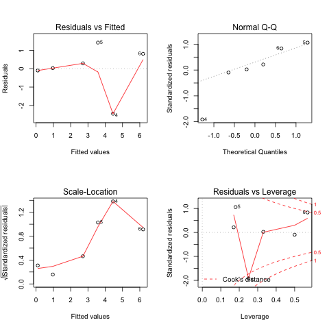

```python
%%R -i x,y -o mycoef # 一定要將 %%R 放在 cell 開頭
# 並且將剛剛的 python變數 當作參數丟給 R

xylm = lm(y~x)
mycoef = coef(xylm)
par(mfrow = c(2, 2))
plot(xylm)

print(mycoef)

print(summary(xylm))
ls(xylm)
residuals(xylm)
```